# Universities: Private or Public??

Madeleine Jones, Audrey Himes, Hayden Ratliff

12/01/2021

### Question and Background

As college students attending a public university, the question of whether there are obvious differences between public and private universities is of particular interest. On the surface, the only distinct difference is in university funding. Public universities are funded by state governments while private universities rely on tuition and endowments. However, this single difference can have implications in other areas such as the size of the student body or the tuition cost.

Given the potential differences across private and public universities, our questions are: Is is possible to predict whether a university is private or public based on attributes such as student-faculty ratio or tuition? And if so, what are the attributes with the greatest predictive importance?

### Exploratory Data Analysis

#### Reading and Cleaning the Data

```
## 'data.frame':    777 obs. of  18 variables:
##  $ Private                  : Factor w/ 2 levels "0","1": 2 2 2 2 2 2 2 2 2 2 ...
##  $ AppsRecieved             : int  1660 2186 1428 417 193 587 353 1899 1038 582 ...
##  $ AppsAccepted             : int  1232 1924 1097 349 146 479 340 1720 839 498 ...
##  $ NewStudentsEnrolled      : int  721 512 336 137 55 158 103 489 227 172 ...
##  $ Top10Percent             : int  23 16 22 60 16 38 17 37 30 21 ...
##  $ Top25Percent             : int  52 29 50 89 44 62 45 68 63 44 ...
##  $ FullTimeUndergrads       : int  2885 2683 1036 510 249 678 416 1594 973 799 ...
##  $ PartTimeUndergrads       : int  537 1227 99 63 869 41 230 32 306 78 ...
##  $ OutStateTuition          : int  7440 12280 11250 12960 7560 13500 13290 13868 15595 10468 ...
##  $ RoomBoardCosts           : int  3300 6450 3750 5450 4120 3335 5720 4826 4400 3380 ...
##  $ BooksCost                : int  450 750 400 450 800 500 500 450 300 660 ...
##  $ PersonalSpendings        : int  2200 1500 1165 875 1500 675 1500 850 500 1800 ...
##  $ FacultyPhDPercentage     : int  70 29 53 92 76 67 90 89 79 40 ...
##  $ FacultyTerminalPercentage: int  78 30 66 97 72 73 93 100 84 41 ...
##  $ StudentFacultyRatio      : num  18.1 12.2 12.9 7.7 11.9 9.4 11.5 13.7 11.3 11.5 ...
##  $ DonatingAlumniPercentage : int  12 16 30 37 2 11 26 37 23 15 ...
##  $ ExpenditurePerStudent    : int  7041 10527 8735 19016 10922 9727 8861 11487 11644 8991 ...
##  $ GraduationRate           : int  60 56 54 59 15 55 63 73 80 52 ...
```

#### Variable Summaries and Graphs

##### Variable Averages by Unversity Type

|  | Variable Mean Values | Public | Private | Percent Difference |
| --- | --- | --- | --- | --- |
| 1 | FullTimeUndergrads | 8571.00471698113 | 1872.16814159292 | 357.81 |
| 2 | PartTimeUndergrads | 1978.18867924528 | 433.966371681416 | 355.84 |
| 3 | NewStudentsEnrolled | 1640.87264150943 | 456.945132743363 | 259.1 |
| 4 | AppsAccepted | 3919.28773584906 | 1305.70265486726 | 200.17 |
| 5 | AppsRecieved | 5729.91981132075 | 1977.92920353982 | 189.69 |
| 6 | DonatingAlumniPercentage | 14.3584905660377 | 25.8902654867257 | 44.54 |
| 7 | OutStateTuition | 6813.41037735849 | 11801.6938053097 | 42.27 |
| 8 | PersonalSpendings | 1676.98113207547 | 1214.4407079646 | 38.09 |
| 9 | StudentFacultyRatio | 17.1391509433962 | 12.9454867256637 | 32.39 |
| 10 | ExpenditurePerStudent | 7458.31603773585 | 10486.3539823009 | 28.88 |

[output cut: 7 more lines]

##### Notable Variable Distributions by University Type

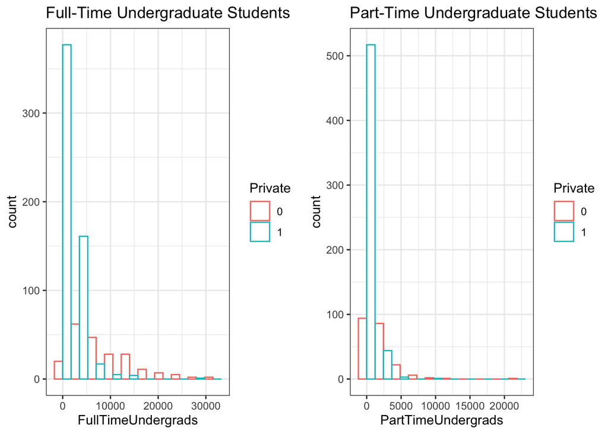

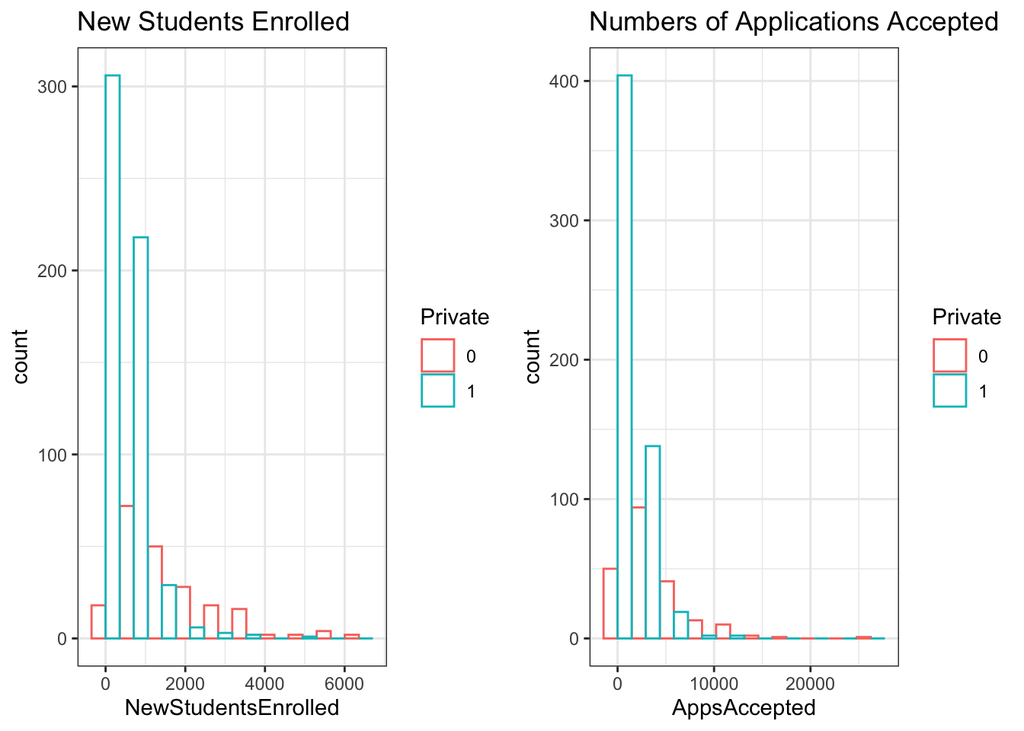

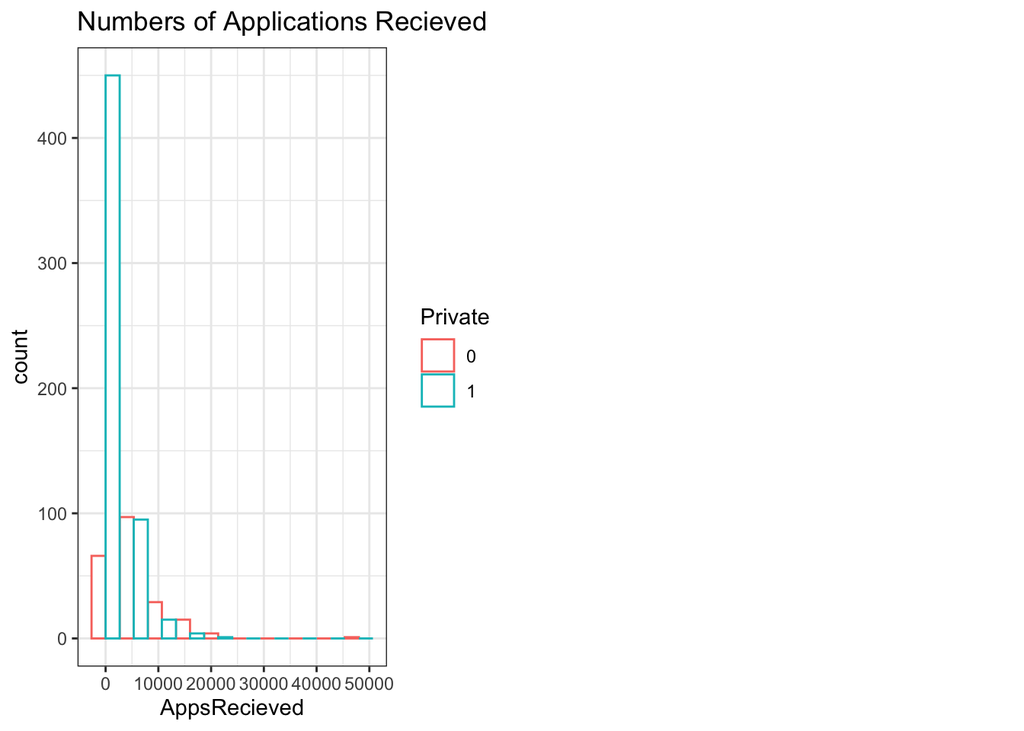

#### Exploratory Variable Analysis Conclusions

First looking at the mean values table, the variables that have the greatest percent difference between private and public schools are the number of full-time undergraduate students, the number of part-time undergraduate students, the number of new students enrolled, the number of applications accepted, and the number of applications received.

### Methods

In order to address our question of whether we can predict if a university is private or public, we will build a kNN model. k-Nearest Neighbors, abbreviated kNN, is a supervised memory-based machine learning technique in which the classification of an observation is based on the majority of the “nearest neighbors,” observations that have the most similar variable values. In our case, the kNN model will classify universities as public or private based on whether the observations that have the most similar attributes, such as graduation rate and tuition, are public or private. The first step to building a kNN model is training the model on a training data set that is separate from the tuning data set and the testing data set. Separate training, tuning, and testing data sets are necessary to ensure that the model is evaluated on data that is independent from the data it was trained on. The model will then be tuned using the tune set, and once the model is optimized, it will be evaluated using the test data set.

In order to address our question of which attributes have the greatest predictive importance in determining whether a university is public or private, we will examine the variable importance metrics for each attribute included in our model. The variables with greater importance in our model are the variables that are most indicative of whether a university is public or private.

#### Creating Train, Tune, and Test Data Sets

The data set observations will be split into train, tune, and test sets such that 60% of the data is used to train the kNN model, 20% of the data is used to tune the model, and 20% is used to test and evaluate the model.

|  | Train | Tune | Test |
| --- | --- | --- | --- |
| Number of Observations | 467 | 155 | 155 |

#### Prevalence as a Baseline

Prevalence =

```
## [1] 0.7271557
```

The positive class prevalence is 0.727, meaning that roughly 73% of the data is private universities. We will use this metric as a baseline because a model that predicts solely the positive class, private universities, for every observation will be correct around 73% of the time. Therefore, for our model to be useful, we are looking for an accuracy of greater than 0.73.

#### Training and Tuning a kNN Model

##### Training Model on Train Set

Using the 467 observations in the train set, the model training has determined that 7 is the best number of nearest-neighbors to use in predicting whether an observation is private or public based on accuracy.

```
## k-Nearest Neighbors
##
## 467 samples
##  17 predictor
##   2 classes: '0', '1'
##
## Pre-processing: scaled (17)
## Resampling: Cross-Validated (10 fold, repeated 3 times)
## Summary of sample sizes: 421, 420, 420, 420, 420, 421, ...
## Resampling results across tuning parameters:
##
##   k   Accuracy   Kappa
##    5  0.9364142  0.8384783
##    7  0.9378789  0.8399838
##    9  0.9300312  0.8175698
##   11  0.9229236  0.7979417
##   13  0.9249734  0.8026258
##   15  0.9242951  0.8011008
##   17  0.9242796  0.8009441
##   19  0.9250043  0.8017798
##   21  0.9207335  0.7904686
##   23  0.9242796  0.7995971
##
## Accuracy was used to select the optimal model using the largest value.
## The final value used for the model was k = 7.
```

##### Tuning Model on Tune Set

The trained kNN model is used to predict public and private universities on the tune set. The results are summarized in the following confusion matrix.

```
## Confusion Matrix and Statistics
##
##           Reference
## Prediction   0   1
##          0  33   4
##          1   9 109
##
##                Accuracy : 0.9161
##                  95% CI : (0.8608, 0.9546)
##     No Information Rate : 0.729
##     P-Value [Acc > NIR] : 5.148e-09
##
##                   Kappa : 0.7795
##
##  Mcnemar's Test P-Value : 0.2673
##
##             Sensitivity : 0.7857
##             Specificity : 0.9646
##          Pos Pred Value : 0.8919
##          Neg Pred Value : 0.9237
##               Precision : 0.8919
##                  Recall : 0.7857
##                      F1 : 0.8354
##              Prevalence : 0.2710
##          Detection Rate : 0.2129
##    Detection Prevalence : 0.2387
##       Balanced Accuracy : 0.8752
##
##        'Positive' Class : 0
##
```

```
## Confusion Matrix and Statistics
##
##           Actual
## Prediction   0   1
##          0  36  10
##          1   6 103
##
##                Accuracy : 0.8968
##                  95% CI : (0.8378, 0.9398)
##     No Information Rate : 0.729
##     P-Value [Acc > NIR] : 2.395e-07
##
##                   Kappa : 0.7463
##
##  Mcnemar's Test P-Value : 0.4533
##
##             Sensitivity : 0.9115
##             Specificity : 0.8571
##          Pos Pred Value : 0.9450
##          Neg Pred Value : 0.7826
##               Precision : 0.9450
##                  Recall : 0.9115
##                      F1 : 0.9279
##              Prevalence : 0.7290
##          Detection Rate : 0.6645
##    Detection Prevalence : 0.7032
##       Balanced Accuracy : 0.8843
##
##        'Positive' Class : 1
##
```

#### Result of kNN Model Building Method

Evaluation will continue on the kNN model using k = 7 and a threshold of 0.6. Evaluation of this model will be used to answer our questions of whether is it possible to predict if a university is private or public and which attributes are most important in this prediction.

### Evaluation

#### Evaluate Model on Test Set using Key Metrics

The kNN model has been used to predict private and public universities on the test set so that our evaluation data is independent of our training and tuning data. The results are summarized in the confusion matrix below.

[output not shown]

The model performs similarly well on the test set as it does the tune set. This consistency in all performance metrics is indicative that our model is able to be generalized, and is not over-fit to the training or tuning sets. The accuracy metric, the metric which our parameter k = 7 was chosen on, of roughly 91% indicates that broadly the model does an excellent job of classifying universities as public or private.

However, given that our data set is not balanced in the target class, private vs public, this metric can overlook discrepancies between predicting capabilities on the positive and negative classes. Therefore, instead of focusing on accuracy, we will look at F1 Score. F1 Score uses the harmonic mean to evaluate accuracy which is more sensitive to imbalances between precision and sensitivity that result from an unbalanced target class as we have in our data set. The F1 Score is roughly 94% for our model when predicting on the test set. This large F1 Score indicates that our model predicts well for both private and public universities.

Further, given that both our accuracy of 91% and F1 score of 94% are above our prevalence baseline of 73%, we can conclude that this model does have added benefits compared to a single-class predicting model. Therefore, this model can be used to predict whether universities are public or private with significant confidence and ability.

#### Evaluate Variable Importance Metric

```
## ROC curve variable importance
##
##                           Importance
## FullTimeUndergrads          100.0000
## OutStateTuition              91.5194
## NewStudentsEnrolled          89.7553
## PartTimeUndergrads           84.1304
## StudentFacultyRatio          78.3899
## AppsAccepted                 75.5666
## AppsRecieved                 72.3024
## DonatingAlumniPercentage     63.5072
## GraduationRate               48.2486
## ExpenditurePerStudent        45.9784
## PersonalSpendings            45.7326
## RoomBoardCosts               30.9149
## Top10Percent                 23.3706
## FacultyPhDPercentage          5.4152
## BooksCost                     0.7700
## Top25Percent                  0.2747
## FacultyTerminalPercentage     0.0000
```

The variables with greater importance have larger measures towards 100 while the variables with lesser importance have smaller measures towards 0. In the kNN model predicting private and public universities, the metrics with the greatest importance are the number of full-time undergraduate students and out-of-state tuition, while the metrics with the least importance are faculty PhD percentage, cost of books, percentage of students in the top 25% of their class, and faculty terminal percentage.

### Conclusions

Our model does well at predicting private and public universities so in regards to the first question it is possible to predict whether a university is public or private.

To answer the second question, the variables will the greatest importance are the number of full-time undergraduate students, the out-of-state tuition, the number of new students enrolled, the number of part-time undergraduate students, the student to faculty ratio, the number of applications accepted, the number of applications received, and the percentage of alumni who donate.

### Future Work

Limitations: - Data set has information for 777 universities in the US, could be expanded to more - Data set only includes out-of-state tuition. Having tuition for in-state tuition could help increase the accuracy of our model further as in-state students normally pay much less for public schools than private schools.